# Time_Series

Joseph Rickert

March 22, 2016

## BASIC TIME SERIES FORECASTING WITH R

This module provides an introduction to time series forecasting using some of the high level functions frovided by R.

### Load the packages required

```r
library(dplyr)             # For data manipulation
library(reshape2)          # Also for data manipulation
library(xts)               # For creating time series objects
library(forecast)          # For automatic forecasting
```

```r
library(ggplot2)           # For visualization
```

### Fetch the data and shape it for analysis

We will use the IBM stock data that we downloaded from Hahoo Finance and saved in a .csv file in a previous module.

```r
# Read the IBM data from the .csv file
dir <- "C:/DATA/IBM"
fileName <- "IBM.stock.csv"
file <- file.path(dir,fileName)

IBM <- read.csv(file)
head(IBM,2)
```

```
##         Date   Open   High    Low  Close  Volume Adj.Close
## 1 2016-02-01 124.40 125.29 123.71 124.83 3574900  123.5678
## 2 2016-01-29 123.28 124.79 122.96 124.79 8248100  123.5282
```

```r
tail(IBM,2)
```

```
##             Date     Open     High      Low    Close Volume Adj.Close
## 13613 1962-01-03 572.0002 576.9997 572.0002 576.9997 288000  2.343201
## 13614 1962-01-02 578.4997 578.4997 572.0002 572.0002 387200  2.322898
```

```r
# Filter out data before 2001
IBM2 <- filter(IBM, as.Date(Date) > as.Date('2000-01-01'))
# Select only Date and Closing Price
IBM2 <- select(IBM2,Date,Close)
head(IBM2,2)
```

```
##         Date  Close
## 1 2016-02-01 124.83
## 2 2016-01-29 124.79
```

```r
sapply(IBM2,class)
```

```
##      Date     Close
##  "factor" "numeric"
```

```r
# Make Date into a Date object
IBM2 <- mutate(IBM2, Date = as.Date(Date))
# Sort in ascending order
IBM2 <- arrange(IBM2,Date)
head(IBM2,2)
```

```
##         Date    Close
## 1 2000-01-03 116.0000
## 2 2000-01-04 112.0625
```

### Create a Time Series Object

We formulate the IBM data as a time series object and then extract a small set of the data to use for training a forecasting model. We will not use the entire series to train the model so we can compare the forecasted prices with the actual recorded values.

```r
# Build a time series object
IBM_ts <- xts(IBM2$Close,order.by=IBM2$Date)
head(IBM_ts)
```

```
##                [,1]
## 2000-01-03 116.0000
## 2000-01-04 112.0625
## 2000-01-05 116.0000
## 2000-01-06 114.0000
## 2000-01-07 113.5000
## 2000-01-10 118.0000
```

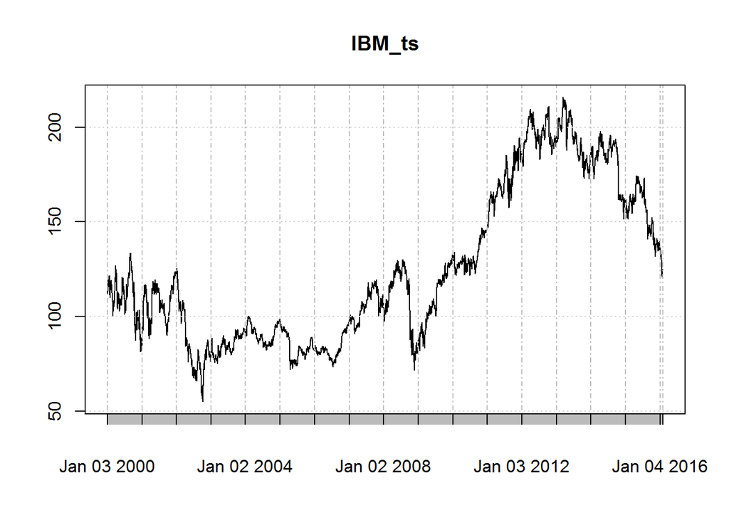

```r
plot(IBM_ts)
```

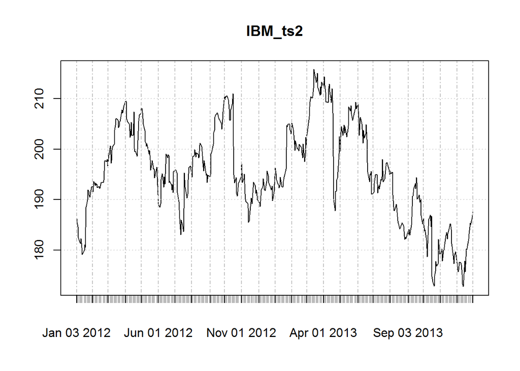

```r
# Narrow down the time series for analysis
IBM_ts2 <- IBM_ts['2012-01/2013']
plot(IBM_ts2)
```

### Fit an ARIMA Model and Forecast We use the functions int the forecast package to futomatically fit an Autoregressive Integrated Moving Average model and generate a forecast.

```r
# Automatically fit an ARIMA Model
fit <- auto.arima(IBM_ts2)
summary(fit)
```

```
## Series: IBM_ts2
## ARIMA(0,1,0) with drift
##
## Coefficients:
##        drift
##       0.0025
## s.e.  0.0962
##
## sigma^2 estimated as 4.637:  log likelihood=-1095.15
## AIC=2194.3   AICc=2194.32   BIC=2202.73
##
## Training set error measures:
##                        ME     RMSE      MAE          MPE      MAPE
## Training set 0.0003711103 2.151137 1.492826 -0.005886632 0.7670946
##                   MASE       ACF1
## Training set 0.9982595 0.06383284
```

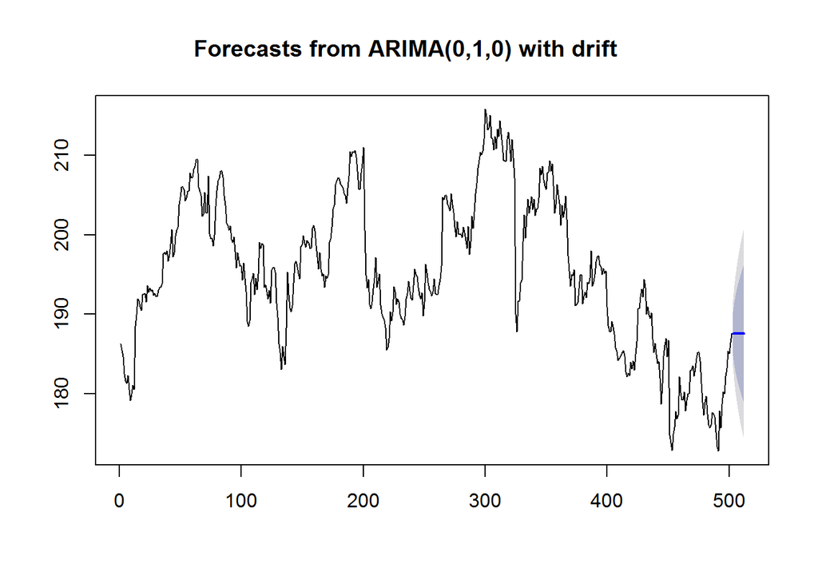

```r
# Generate and automatic forecast
fore <- forecast(fit)
plot(fore)
```

```r
fore
```

```
##     Point Forecast    Lo 80    Hi 80    Lo 95    Hi 95
## 503       187.5725 184.8130 190.3321 183.3522 191.7929
## 504       187.5751 183.6725 191.4776 181.6066 193.5435
## 505       187.5776 182.7980 192.3572 180.2678 194.8874
## 506       187.5801 182.0611 193.0992 179.1395 196.0208
## 507       187.5827 181.4122 193.7532 178.1457 197.0196
## 508       187.5852 180.8258 194.3446 177.2476 197.9229
## 509       187.5878 180.2867 194.8888 176.4218 198.7537
## 510       187.5903 179.7852 195.3954 175.6534 199.5272
## 511       187.5928 179.3143 195.8714 174.9318 200.2538
## 512       187.5954 178.8690 196.3217 174.2495 200.9412
```

### Plot the Data with the Forecast

We build a data frame to containg the forecasted results along with the relevant portion of the actual IBM stock price data.

```r
# Build a common data frame for forecast
Jan2014<- IBM_ts['2014-01']
Jan_data <- as.data.frame(Jan2014)
row.names(Jan_data)
```

```
##  [1] "2014-01-02" "2014-01-03" "2014-01-06" "2014-01-07" "2014-01-08"
##  [6] "2014-01-09" "2014-01-10" "2014-01-13" "2014-01-14" "2014-01-15"
## [11] "2014-01-16" "2014-01-17" "2014-01-21" "2014-01-22" "2014-01-23"
## [16] "2014-01-24" "2014-01-27" "2014-01-28" "2014-01-29" "2014-01-30"
## [21] "2014-01-31"
```

```r
res <- data.frame(row.names(Jan_data)[1:10],Jan2014[1:10,1],
                  fore$mean,fore$lower[,1],
                  fore$upper[,1],
                  row.names = NULL)
names(res) <- c("Date", "Actual","Point","Lower","Upper")
res
```

```
##          Date Actual    Point    Lower    Upper
## 1  2014-01-02 185.53 187.5725 184.8130 190.3321
## 2  2014-01-03 186.64 187.5751 183.6725 191.4776
## 3  2014-01-06 186.00 187.5776 182.7980 192.3572
## 4  2014-01-07 189.71 187.5801 182.0611 193.0992
## 5  2014-01-08 187.97 187.5827 181.4122 193.7532
## 6  2014-01-09 187.38 187.5852 180.8258 194.3446
## 7  2014-01-10 187.26 187.5878 180.2867 194.8888
## 8  2014-01-13 184.16 187.5903 179.7852 195.3954
## 9  2014-01-14 185.92 187.5928 179.3143 195.8714
## 10 2014-01-15 187.74 187.5954 178.8690 196.3217
```

```r
meltdf <- melt(res,id="Date")
```

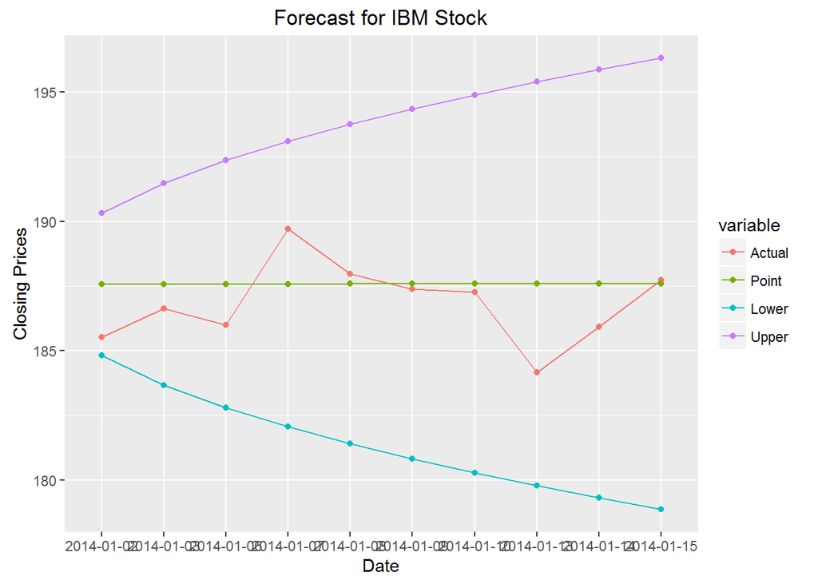

```r
p <- ggplot(meltdf,aes(x=Date,y=value,colour=variable,group=variable))
p +  geom_line() + geom_point() +
  ylab("Closing Prices") +
  ggtitle("Forecast for IBM Stock")
```

We have just scratched the surface of R’s time series capabilities. For an over of all that is available in R look at the CRAN Task View: Time Series Analysis which can be found here: https://cran.r-project.org/web/views/TimeSeries.html

For a complete introductory time series course usng R seee the online book from Rob J Hyndman and George Athanasopoulos: https://www.otexts.org/fpp